# Problem Set 2

Author

Aryan Singh

https://github.com/aryansinghmich/stats_506

```r
# environment set up
setwd("/Users/aryansingh/Desktop/stats_506_git/hw2")
pacman::p_load(tidyverse, microbenchmark, cowplot)
```

# Problem 1

## Part A

```r
#' random walk version 1 - loop based
#'
#' Simulates a 1D random walk using a loop. Each step is +1 or -1
#' with equal probability. A +1 step has a 5% chance of being +10,
#' while a -1 step has a 20% chance of being -3.
#'
#' @param n_steps Number of steps (must be > 0)
#' @param seed Optional random seed for reproducibility
#' @return Final position after n_steps
random_walk1 <- function(n_steps, seed = NULL) {
    pos <- 0
    for (i in 1:n_steps) {
        step <- sample(c(-1, 1), size = 1)
        if (step == 1) {
            if (runif(1) <0.05) {
                step <- 10
            }
        } else {
            if (runif(1) <0.2) {
                step <- -3
            }
        }
        pos <- pos + step
    }
    return(pos)
}

#' random walk version 2 - vectorized
#'
#' Simulates the same random walk as `random_walk1`, but uses
#' vectorized operations instead of a loop
#'
#' @param n_steps Number of steps (must be > 0)
#' @return Final position after n_steps
random_walk2 <- function(n_steps) {
    base_steps <- sample(c(-1, 1), size = n_steps, replace = TRUE)

    random_factor <- runif(n_steps)
    steps <- ifelse(base_steps == 1 & random_factor < 0.05, 10, base_steps) # +1 case
    steps <- ifelse(base_steps == -1 & random_factor < 0.20, -3, steps) # -1 case

    return(sum(steps))
}

#' random walk version 3 - apply function
#'
#' Simulates the same random walk as `random_walk1`, but uses
#' an inner function with `vapply` to generate steps.
#'
#' @param n_steps Number of steps (must be > 0)
#' @return Final position after n_steps
random_walk3 <- function(n_steps) {
    one_step <- function(i) {
        base <- if (runif(1) < 0.5) -1 else 1
        if (base == 1) {
            if (runif(1) < 0.05) 10 else 1
        } else {
            if (runif(1) < 0.20) -3 else -1
        }
    }
    steps <- vapply(seq_len(n_steps), one_step, numeric(1))
    return(sum(steps))
}
```

```r
random_walk1(10)
```

```
[1] -12
```

```r
random_walk2(10)
```

```
[1] 15
```

```r
random_walk3(10)
```

```
[1] 15
```

```r
random_walk1(1000)
```

```
[1] 78
```

```r
random_walk2(1000)
```

```
[1] 112
```

```r
random_walk3(1000)
```

```
[1] -32
```

## Part B

```r
#' random walk helper - direction
#'
#' Converts uniform draws into base steps (-1 or +1).
#' This helper is used in the rewritten random walk functions below
#' to separate direction from modification (-1 turning into -3 or +1 turning into +10)
#'
#' @param u_dir Numeric vector of uniform(0,1) draws
#' @return Vector of -1 or +1 base steps
u_to_base <- function(u_dir) ifelse(u_dir < 0.5, -1, 1)

#' random walk version 1 - loop based (rewritten with seed)
#'
#' Rewrites the earlier loop-based `random_walk1` to include
#' an optional seed for reproducibility. Pre-generates the random
#' numbers for direction and modification, then uses a loop
#' to accumulate the final position.
#'
#' @param n_steps Number of steps (must be > 0)
#' @param seed Optional random seed for reproducibility
#' @return Final position after n_steps
random_walk1 <- function(n_steps, seed = NULL) {
  if (!is.null(seed)) set.seed(seed)
  u_dir <- runif(n_steps)
  u_mod <- runif(n_steps)
  base_steps <- u_to_base(u_dir)

  pos <- 0
  for (i in seq_len(n_steps)) {
    base <- base_steps[i]
    u <- u_mod[i]
    step <- if (base == 1) {
      if (u < 0.05) 10 else 1
    } else {
      if (u < 0.20) -3 else -1
    }
    pos <- pos + step
  }
  pos
}

#' random walk version 2 - vectorized (rewritten with seed)
#'
#' Rewrites the earlier vectorized `random_walk2` to include
#' an optional seed for reproducibility. Uses pre-generated
#' random draws for direction and modification, then applies
#' vectorized ifelse logic.
#'
#' @param n_steps Number of steps (must be > 0)
#' @param seed Optional random seed for reproducibility
#' @return Final position after n_steps
random_walk2 <- function(n_steps, seed = NULL) {
  if (!is.null(seed)) set.seed(seed)
  u_dir <- runif(n_steps)
  u_mod <- runif(n_steps)
  base_steps <- u_to_base(u_dir)

  steps <- ifelse(base_steps == 1,
                  ifelse(u_mod < 0.05, 10, 1),
                  ifelse(u_mod < 0.20, -3, -1))
  sum(steps)
}

#' random walk version 3 - apply function (rewritten with seed)
#'
#' Rewrites the earlier apply-based `random_walk3` to include
#' an optional seed for reproducibility. Uses pre-generated
#' random draws and an inner function with vapply to calculate
#' the steps.
#'
#' @param n_steps Number of steps (must be > 0)
#' @param seed Optional random seed for reproducibility
#' @return Final position after n_steps
random_walk3 <- function(n_steps, seed = NULL) {
  if (!is.null(seed)) set.seed(seed)
  u_dir <- runif(n_steps)
  u_mod <- runif(n_steps)
  base_steps <- u_to_base(u_dir)

  one_step <- function(i) {
    base <- base_steps[i]
    u <- u_mod[i]
    if (base == 1) {
      if (u < 0.05) 10 else 1
    } else {
      if (u < 0.20) -3 else -1
    }
  }

  sum(vapply(seq_len(n_steps), one_step, numeric(1)))
}
```

```r
random_walk1(10, 999)
```

```
[1] -4
```

```r
random_walk2(10, 999)
```

```
[1] -4
```

```r
random_walk3(10, 999)
```

```
[1] -4
```

```r
random_walk1(1000, 999)
```

```
[1] -20
```

```r
random_walk2(1000, 999)
```

```
[1] -20
```

```r
random_walk3(1000, 999)
```

```
[1] -20
```

## Part C

```r
b1k <- microbenchmark(
  loop = random_walk1(1000, seed = 981),
  vectorized = random_walk2(1000, seed = 981),
  apply = random_walk3(1000, seed = 981)
)
b100k <- microbenchmark(
  loop = random_walk1(100000, seed = 981),
  vectorized = random_walk2(100000, seed = 981),
  apply = random_walk3(100000, seed = 981)
)

print(summary(b1k), digits = 3)
```

```
        expr   min    lq  mean median    uq  max neval cld
1       loop  86.3  89.2  92.5   90.8  94.3  119   100  a
2 vectorized  72.0  79.8  92.5   89.8 102.2  187   100  a
3      apply 449.4 475.0 541.1  507.3 533.4 3609   100   b
```

```r
print(summary(b100k), digits = 3)
```

```
        expr   min    lq  mean median    uq  max neval cld
1       loop  8.49  8.88  9.52   9.07  9.58 17.0   100  a
2 vectorized  7.02  7.79  9.50   8.45  9.69 52.4   100  a
3      apply 46.52 49.40 51.82  50.63 51.71 89.3   100   b
```

The benchmarking shows that both the loop and vectorized implementations perform similarly and efficiently, with vectorization offering a slight advantage at larger inputs. The apply-based version is consistently much slower, especially at the larger inputs.

## Part D

```r
# Monte Carlo
simulate_p0 <- function(n_steps, n_sims, seed) {
  set.seed(seed)

  totals <- replicate(n_sims, random_walk2(n_steps)) # using fastest function

  k <- sum(totals == 0L)
  phat <- k / n_sims
  se <- sqrt(phat * (1 - phat) / n_sims)
  ci <- phat + c(-1, 1) * 1.96 * se

  data.frame(n_steps = n_steps, simulations = n_sims, zero_count = k,
    p_hat = phat, std_error = se, ci95_low = max(0, ci[1]), ci95_high = min(1, ci[2]))
}

res_10   <- simulate_p0(10, n_sims = 1e5, seed = 987)
res_100  <- simulate_p0(100, n_sims = 1e5, seed = 987)
res_1000 <- simulate_p0(1000, n_sims = 1e5, seed = 987)

results <- rbind(res_10, res_100, res_1000)
print(results, row.names = FALSE, digits = 6)
```

```
 n_steps simulations zero_count   p_hat   std_error   ci95_low  ci95_high
      10       1e+05      13285 0.13285 0.001073317 0.13074630 0.13495370
     100       1e+05       1917 0.01917 0.000433619 0.01832011 0.02001989
    1000       1e+05        574 0.00574 0.000238894 0.00527177 0.00620823
```

The Monte Carlo simulation shows that the probability of the walk ending at zero decreases as the number of steps increases. With 10 steps, the chance is about 13%, dropping to a little less than 2% for 100 steps and less than 1% for 1000 steps. This pattern shows how the distribution spreads out as the walk gets longer thus making it way less likely to land exactly at zero.

# Problem 2

```r
set.seed(10887)
mcrep <- 1e6

tot <- rowSums(matrix(rpois(mcrep * 8, 1),  ncol = 8)) +
       pmax(0, round(rnorm(mcrep, mean = 60, sd = sqrt(12)))) +
       rowSums(matrix(rpois(mcrep * 8, 8),  ncol = 8)) +
       pmax(0, round(rnorm(mcrep, mean = 60, sd = sqrt(12)))) +
       rowSums(matrix(rpois(mcrep * 6, 12), ncol = 6))

est <- mean(tot) # Monte Carlo estimate E[cars/day]
se  <- sd(tot) / sqrt(mcrep) # MC standard error (CLT)
ci  <- est + c(-1, 1) * 1.96 * se # 95% CI

c(estimate = est, mc_se = se, ci_low = ci[1], ci_high = ci[2])
```

```
    estimate        mc_se       ci_low      ci_high
264.01912300   0.01296444 263.99371269 264.04453331
```

# Problem 3

## Part A

```r
youtube <- read.csv('https://raw.githubusercontent.com/rfordatascience/tidytuesday/master/data/2021/2021-03-02/youtube.csv')
dim(youtube) # before
```

```
[1] 247  25
```

```r
drop_cols <- c("brand", "superbowl_ads_dot_com_url", "youtube_url",
               "id", "etag", "published_at", "title",
               "description", "thumbnail", "channel_title")

youtube <- youtube[, !(names(youtube) %in% drop_cols)]
dim(youtube) # after
```

```
[1] 247  15
```

## Part B

```r
vars <- c("view_count", "like_count", "dislike_count", "favorite_count", "comment_count")
summary(youtube %>% select(all_of(vars)))
```

```
   view_count          like_count     dislike_count     favorite_count
 Min.   :       10   Min.   :     0   Min.   :    0.0   Min.   :0
 1st Qu.:     6431   1st Qu.:    19   1st Qu.:    1.0   1st Qu.:0
 Median :    41379   Median :   130   Median :    7.0   Median :0
 Mean   :  1407556   Mean   :  4146   Mean   :  833.5   Mean   :0
 3rd Qu.:   170016   3rd Qu.:   527   3rd Qu.:   24.0   3rd Qu.:0
 Max.   :176373378   Max.   :275362   Max.   :92990.0   Max.   :0
 NA's   :16          NA's   :22       NA's   :22        NA's   :16
 comment_count
 Min.   :   0.00
 1st Qu.:   1.00
 Median :  10.00
 Mean   : 188.64
 3rd Qu.:  50.75
 Max.   :9190.00
 NA's   :25
```

Based on this summary of variables, favorite_count has all values at 0 (with a few NAs) and thus has no explanatory power becuase it has no variation (cannot be modeled effectively as an outcome)

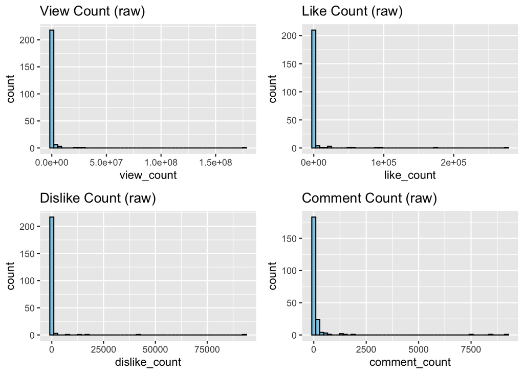

```r
raw1 <- ggplot(youtube, aes(x = view_count)) +
  geom_histogram(bins = 50, fill = "skyblue", color = "black") +
  labs(title = "View Count (raw)")

raw2 <- ggplot(youtube, aes(x = like_count)) +
  geom_histogram(bins = 50, fill = "skyblue", color = "black") +
  labs(title = "Like Count (raw)")

raw3 <- ggplot(youtube, aes(x = dislike_count)) +
  geom_histogram(bins = 50, fill = "skyblue", color = "black") +
  labs(title = "Dislike Count (raw)")

raw4 <- ggplot(youtube, aes(x = comment_count)) +
  geom_histogram(bins = 50, fill = "skyblue", color = "black") +
  labs(title = "Comment Count (raw)")

raw_plot <- plot_grid(raw1, raw2, raw3, raw4, ncol = 2)
raw_plot
```

The histograms of the other raw count variables show that the data is heavily right-skewed, with most commercials clustered at very low counts and a few with extremely large values. As they are, these variables are extremely skewed and would need a log transformation before using them to model outcomes.

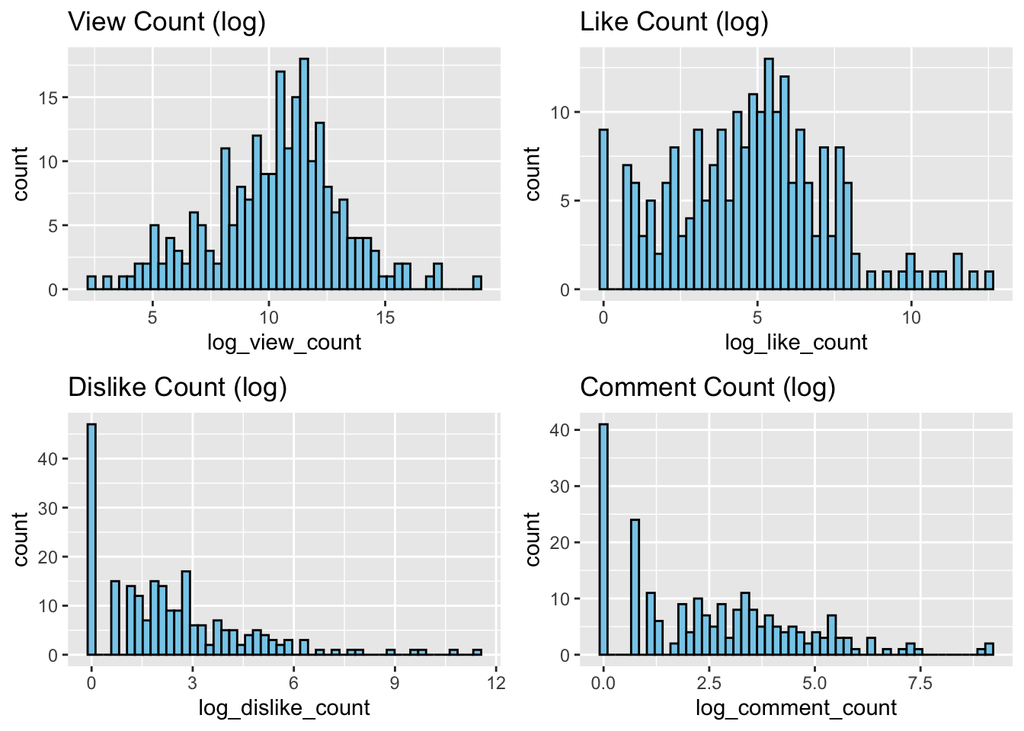

```r
# use log1p (log(x+1)) instead of log(x) so that zero counts are handled safely;
# plain log(0) would produce -Inf values and break the lm models in Part C
youtube$log_view_count <- log1p(youtube$view_count)
youtube$log_like_count <- log1p(youtube$like_count)
youtube$log_dislike_count <- log1p(youtube$dislike_count)
youtube$log_comment_count <- log1p(youtube$comment_count)

log1 <- ggplot(youtube, aes(x = log_view_count)) +
  geom_histogram(bins = 50, fill = "skyblue", color = "black") +
  labs(title = "View Count (log)")

log2 <- ggplot(youtube, aes(x = log_like_count)) +
  geom_histogram(bins = 50, fill = "skyblue", color = "black") +
  labs(title = "Like Count (log)")

log3 <- ggplot(youtube, aes(x = log_dislike_count)) +
  geom_histogram(bins = 50, fill = "skyblue", color = "black") +
  labs(title = "Dislike Count (log)")

log4 <- ggplot(youtube, aes(x = log_comment_count)) +
  geom_histogram(bins = 50, fill = "skyblue", color = "black") +
  labs(title = "Comment Count (log)")

log_plot <- plot_grid(log1, log2, log3, log4, ncol = 2)
log_plot
```

After the log transformation, the distributions look much more balanced and less skewed, making them much more suitable for use as outcomes in linear regression models. Though dislike count and comment count still have right skewed distributions after transformation we will continue to use them as outcome variables.

## Part C

```r
predictors <- "funny + show_product_quickly + patriotic + celebrity + danger + animals + use_sex + year"

# fit models
# NA values rows are dropped based on the outcome variable column in order to run lm
m_view <- lm(as.formula(paste("log_view_count ~", predictors)),
                data = subset(youtube, !is.na(log_view_count)))
m_like <- lm(as.formula(paste("log_like_count ~", predictors)),
                data = subset(youtube, !is.na(log_like_count)))
m_dis <- lm(as.formula(paste("log_dislike_count ~", predictors)),
                data = subset(youtube, !is.na(log_dislike_count)))
m_comm <- lm(as.formula(paste("log_comment_count ~", predictors)),
                data = subset(youtube, !is.na(log_comment_count)))

summary(m_view)
```

```
Call:
lm(formula = as.formula(paste("log_view_count ~", predictors)),
    data = subset(youtube, !is.na(log_view_count)))

Residuals:
    Min      1Q  Median      3Q     Max
-7.7742 -1.6152  0.1311  1.7036  8.4481

Coefficients:
                          Estimate Std. Error t value Pr(>|t|)
(Intercept)              -31.55016   71.00538  -0.444    0.657
funnyTRUE                  0.56492    0.46702   1.210    0.228
show_product_quicklyTRUE   0.21089    0.40530   0.520    0.603
patrioticTRUE              0.50699    0.53811   0.942    0.347
celebrityTRUE              0.03548    0.42228   0.084    0.933
dangerTRUE                 0.63131    0.41812   1.510    0.132
animalsTRUE               -0.31002    0.39348  -0.788    0.432
use_sexTRUE               -0.38671    0.44782  -0.864    0.389
year                       0.02053    0.03531   0.582    0.561

Residual standard error: 2.787 on 222 degrees of freedom
Multiple R-squared:  0.02694,   Adjusted R-squared:  -0.008122
F-statistic: 0.7684 on 8 and 222 DF,  p-value: 0.631
```

```r
summary(m_like)
```

```
Call:
lm(formula = as.formula(paste("log_like_count ~", predictors)),
    data = subset(youtube, !is.na(log_like_count)))

Residuals:
    Min      1Q  Median      3Q     Max
-5.2860 -1.6333  0.0868  1.4911  7.7431

Coefficients:
                           Estimate Std. Error t value Pr(>|t|)
(Intercept)              -150.51357   63.45723  -2.372   0.0186 *
funnyTRUE                   0.47476    0.41816   1.135   0.2575
show_product_quicklyTRUE    0.20017    0.36391   0.550   0.5828
patrioticTRUE               0.80689    0.49791   1.621   0.1066
celebrityTRUE               0.41283    0.38212   1.080   0.2812
dangerTRUE                  0.63895    0.37350   1.711   0.0886 .
animalsTRUE                -0.05944    0.35298  -0.168   0.8664
use_sexTRUE                -0.42952    0.40064  -1.072   0.2849
year                        0.07685    0.03155   2.436   0.0157 *
---
Signif. codes:  0 '***' 0.001 '**' 0.01 '*' 0.05 '.' 0.1 ' ' 1

Residual standard error: 2.467 on 216 degrees of freedom
Multiple R-squared:  0.07313,   Adjusted R-squared:  0.03881
F-statistic:  2.13 on 8 and 216 DF,  p-value: 0.0342
```

```r
summary(m_dis)
```

```
Call:
lm(formula = as.formula(paste("log_dislike_count ~", predictors)),
    data = subset(youtube, !is.na(log_dislike_count)))

Residuals:
    Min      1Q  Median      3Q     Max
-4.0292 -1.3299 -0.3192  0.8986  8.7219

Coefficients:
                           Estimate Std. Error t value Pr(>|t|)
(Intercept)              -183.06813   53.34768  -3.432 0.000719 ***
funnyTRUE                   0.25949    0.35154   0.738 0.461224
show_product_quicklyTRUE    0.27511    0.30593   0.899 0.369515
patrioticTRUE               0.81407    0.41859   1.945 0.053095 .
celebrityTRUE              -0.20214    0.32125  -0.629 0.529852
dangerTRUE                  0.22184    0.31400   0.707 0.480630
animalsTRUE                -0.21192    0.29675  -0.714 0.475911
use_sexTRUE                -0.32980    0.33681  -0.979 0.328583
year                        0.09207    0.02653   3.471 0.000626 ***
---
Signif. codes:  0 '***' 0.001 '**' 0.01 '*' 0.05 '.' 0.1 ' ' 1

Residual standard error: 2.074 on 216 degrees of freedom
Multiple R-squared:  0.09753,   Adjusted R-squared:  0.06411
F-statistic: 2.918 on 8 and 216 DF,  p-value: 0.004115
```

```r
summary(m_comm)
```

```
Call:
lm(formula = as.formula(paste("log_comment_count ~", predictors)),
    data = subset(youtube, !is.na(log_comment_count)))

Residuals:
    Min      1Q  Median      3Q     Max
-4.1372 -1.4665 -0.1427  1.4061  5.8468

Coefficients:
                          Estimate Std. Error t value Pr(>|t|)
(Intercept)              -99.09835   52.92351  -1.872   0.0625 .
funnyTRUE                  0.21954    0.34528   0.636   0.5256
show_product_quicklyTRUE   0.40939    0.30229   1.354   0.1771
patrioticTRUE              0.66698    0.39902   1.672   0.0961 .
celebrityTRUE              0.29767    0.31541   0.944   0.3464
dangerTRUE                 0.17784    0.31069   0.572   0.5677
animalsTRUE               -0.26802    0.29347  -0.913   0.3621
use_sexTRUE               -0.39323    0.33163  -1.186   0.2370
year                       0.05034    0.02632   1.913   0.0571 .
---
Signif. codes:  0 '***' 0.001 '**' 0.01 '*' 0.05 '.' 0.1 ' ' 1

Residual standard error: 2.039 on 213 degrees of freedom
Multiple R-squared:  0.06535,   Adjusted R-squared:  0.03025
F-statistic: 1.862 on 8 and 213 DF,  p-value: 0.06748
```

Across the four models, most ad variables were not statistically significant predictors of the ad’s engagement on youtube once year was controlled for. For views, no predictors reached significance. For likes, year was a significant positive predictor (newer ads tended to receive more likes) and danger-themed ads were marginally positive (p ~ 0.09; danger-themed ads tended to receive more likes). For dislikes, year was again a significant positive predictor (newer ads tended to receive more dislikes), while patriotic ads were borderline positive (p ~ 0.05; patriotic ads tended to receive more dislikes). For comments, most were insignificant, though year showed a marginally positive association. Overall, the main consistent finding is that ad engagement (both positive and negative) has increased over time, while other variables like humor, animals, or celebrity presence did not have strong effects.

## Part D

```r
f_view <- as.formula(paste("log_view_count ~", predictors))

X <- model.matrix(f_view, data = youtube[!is.na(youtube$log_view_count), ])
y <- youtube$log_view_count[!is.na(youtube$log_view_count)]

beta_hat <- solve(t(X) %*% X, t(X) %*% y)
beta_hat_qr <- qr.solve(X, y) # alternative way to solve

coef_lm <- coef(m_view) # from Part C

print(cbind(lm = coef_lm, beta_hat = as.numeric(beta_hat), beta_hat_qr = as.numeric(beta_hat_qr)))
```

```
                                   lm     beta_hat  beta_hat_qr
(Intercept)              -31.55015804 -31.55015804 -31.55015804
funnyTRUE                  0.56492445   0.56492445   0.56492445
show_product_quicklyTRUE   0.21088918   0.21088918   0.21088918
patrioticTRUE              0.50699051   0.50699051   0.50699051
celebrityTRUE              0.03547862   0.03547862   0.03547862
dangerTRUE                 0.63131085   0.63131085   0.63131085
animalsTRUE               -0.31001838  -0.31001838  -0.31001838
use_sexTRUE               -0.38670726  -0.38670726  -0.38670726
year                       0.02053399   0.02053399   0.02053399
```